# 01_03_Bankruptcy_Risk_Prediction04_withkaggle_V10

## [은행파산 위기 데이터 분석]

- 개인의 파산을 예측하는 대회
- 대회명 : Bankruptcy Risk Prediction
- 데이터 출처 : https://www.kaggle.com/competitions/bankruptcy-risk-prediction
- 데이터 분석 코드
  - [HTML코드](https://ldjwj.github.io/dataAnalysis/01_03_Bankruptcy_Risk_Prediction04_V10.html)

### 학습 내용

- 대회 개요 및 데이터 설명
- 라이브러리 및 데이터 불러오기
- 데이터 살펴보기(시각화, EDA)

### 목차

01 대회 개요 및 데이터 설명  
02 라이브러리 및 데이터 기본 탐색  
03 데이터 탐색(Exploratory Data Analysis, EDA)  
04 데이터 전처리 및 데이터 나누기  
05 머신러닝 모델 구축/학습/평가

### 01 대회 개요 및 데이터 설명

목차로 이동하기

### 대회 개요

- 대회 측정 지표 : ROC~AUC
  - ROC (Receiver Operating Characteristic) 곡선은 이진 분류 모델의 성능을 평가하는 데 사용되는 그래프입니다. 이 곡선은 모델의 True Positive Rate (TPR)와 False Positive Rate (FPR)를 다양한 임계값에서 비교하여 작성됩니다.
  - AUC (Area Under the Curve)는 ROC 곡선 아래의 면적을 나타내며, 모델의 분류 성능을 하나의 수치로 표현합니다. AUC 값은 0에서 1 사이의 값으로 표현됩니다.
- 예측 : proba - true label 예측 확률
- 데이터 셋
  - test.csv
  - train.csv
  - submission_example.csv

### 데이터에 대한 설명

- train.csv : 800행 22열 (bankruptcy : 파산여부, 타겟변수 0 또는 1)
- test.csv : 200행 21열 (ID 포함, 타겟 변수 없음)
- submission.csv : 200행 2열 (ID와 proba)

### train.csv

| 변수명 | 설명 |
| --- | --- |
| id | 예제의 식별 번호 |
| sum | 대출 금액 |
| term | 대출 기간(월 수) |
| payment | 월 상환액 |
| guarantees | 담보의 종류 |
| reason | 대출 사유 |
| credits | 기존의 대출 수 |
| other_credits | 다른 대출의 상태 |
| credit_report | 신용 보고서 상태 |
| marital_status | 결혼 상태 |
| age | 나이 |
| employment | 고용 기간 |
| qualification | 자격 |
| immigrant | 이민자 여부 |
| residence_since | 현재 거주지에 거주한 기간(년 수) |
| accommodation | 주거 형태 |
| estate | 소유 부동산 |
| savings | 저축 계좌 상태 |
| dependents | 부양 가족 수 |
| phone | 전화 소유 여부 |
| status | 체크 계좌 상태 |
| bankruptcy | 파산 여부(타겟 변수, 0 또는 1) |

### 범주형, 연속형 변수 구분

### 연속형

| 변수명 | 설명 | 예제 값 | 구분 |
| --- | --- | --- | --- |
| term | 대출 기간(월 수) | 6, 48, 12, 42 | 숫자형 |
| sum | 대출 금액 | 1169, 5951, 2096, 7882 | 숫자형 |
| payment | 월 상환액 | 4, 2, 2, 2 | 숫자형 |
| residence_since | 현재 거주지에 거주한 기간(년 수) | 4, 2, 3, 4 | 숫자형 |
| age | 나이 | 67, 22, 49, 45 | 숫자형 |
| credits | 기존의 대출 수 | 2, 1, 1, 1 | 숫자형 |
| dependents | 부양 가족 수 | 1, 1, 2, 2 | 숫자형 |

### 범주형 변수

| 변수명 | 설명 | 예제 값 | 구분 |
| --- | --- | --- | --- |
| status | 체크 계좌 상태 | less-than 0 cu, 0 to 200 cu, no checking account | 범주형 |
| credit_report | 신용 보고서 상태 | critical account or other credits existing (not at this bank), existing credits paid back duly till now | 범주형 |
| reason | 대출 사유 | television or radio, education, furniture or equipment | 범주형 |
| savings | 저축 계좌 상태 | unknown or no savings account, less-than 100 cu | 범주형 |
| employment | 고용 기간 | 7+ y., 1 to 4 y., 4 to 7 y. | 범주형 |
| marital_status | 결혼 상태 | male single, female divorced or separated or married | 범주형 |
| guarantees | 담보의 종류 | none, guarantor | 범주형 |
| estate | 소유 부동산 | real estate, building society savings agreement or life insurance | 범주형 |
| other_credits | 다른 대출의 상태 | none | 범주형 |
| accommodation | 주거 형태 | own, for free | 범주형 |
| qualification | 자격 | skilled employee, unskilled resident | 범주형 |
| phone | 전화 소유 여부 | yes, none | 범주형 |
| immigrant | 이민자 여부 | yes | 범주형 |

### 02 라이브러리 및 데이터 기본탐색

목차로 이동하기

### 라이브러리 불러오기

```python
import pandas as pd
import seaborn as sns
import numpy as np
import matplotlib.pyplot as plt

from sklearn.model_selection import train_test_split
```

### 데이터 불러오기

```python
sub = pd.read_csv("/kaggle/input/bankruptcy-risk-prediction/submission_example.csv")
train = pd.read_csv("/kaggle/input/bankruptcy-risk-prediction/train.csv")
test = pd.read_csv("/kaggle/input/bankruptcy-risk-prediction/test.csv")

train.shape, test.shape, sub.shape
```

```
((800, 22), (200, 21), (200, 2))
```

```python
# 학습용 데이터 셋 컬럼명 확인
train.columns
```

```
Index(['id', 'sum', 'term', 'payment', 'guarantees', 'reason', 'credits',
       'other_credits', 'credit_report', 'marital_status', 'age', 'employment',
       'qualification', 'immigrant', 'residence_since', 'accommodation',
       'estate', 'savings', 'dependents', 'phone', 'status', 'bankruptcy'],
      dtype='object')
```

```python
# 테스트용 데이터 셋 컬럼명 확인
test.columns
```

```
Index(['id', 'sum', 'term', 'payment', 'guarantees', 'reason', 'credits',
       'other_credits', 'credit_report', 'marital_status', 'age', 'employment',
       'qualification', 'immigrant', 'residence_since', 'accommodation',
       'estate', 'savings', 'dependents', 'phone', 'status'],
      dtype='object')
```

- bankruptcy의 컬럼의 값을 예측하는 과제

```python
# bankruptcy(파산 여부)의 값 확인
train['bankruptcy'].unique()
```

```
array([0, 1])
```

```python
# bankruptcy의 값과 개수 확인
train['bankruptcy'].value_counts()
```

```
bankruptcy
0    561
1    239
Name: count, dtype: int64
```

```python
# 데이터 셋의 전반적인 정보 확인
# 컬럼명, 결측치 확인, 컬럼의 자료형 형태 등
train.info()
```

```
<class 'pandas.core.frame.DataFrame'>
RangeIndex: 800 entries, 0 to 799
Data columns (total 22 columns):
 #   Column           Non-Null Count  Dtype
---  ------           --------------  -----
 0   id               800 non-null    int64
 1   sum              800 non-null    int64
 2   term             800 non-null    int64
 3   payment          800 non-null    int64
 4   guarantees       800 non-null    object
 5   reason           800 non-null    object
 6   credits          800 non-null    int64
 7   other_credits    800 non-null    object
 8   credit_report    800 non-null    object
 9   marital_status   800 non-null    object
 10  age              800 non-null    int64
 11  employment       800 non-null    object
 12  qualification    800 non-null    object
 13  immigrant        800 non-null    object
 14  residence_since  800 non-null    int64
 15  accommodation    800 non-null    object
 16  estate           800 non-null    object
 17  savings          800 non-null    object
 18  dependents       800 non-null    int64
 19  phone            800 non-null    object
 20  status           800 non-null    object
 21  bankruptcy       800 non-null    int64
dtypes: int64(9), object(13)
memory usage: 137.6+ KB
```

```python
test.info()
```

```
<class 'pandas.core.frame.DataFrame'>
RangeIndex: 200 entries, 0 to 199
Data columns (total 21 columns):
 #   Column           Non-Null Count  Dtype
---  ------           --------------  -----
 0   id               200 non-null    int64
 1   sum              200 non-null    int64
 2   term             200 non-null    int64
 3   payment          200 non-null    int64
 4   guarantees       200 non-null    object
 5   reason           200 non-null    object
 6   credits          200 non-null    int64
 7   other_credits    200 non-null    object
 8   credit_report    200 non-null    object
 9   marital_status   200 non-null    object
 10  age              200 non-null    int64
 11  employment       200 non-null    object
 12  qualification    200 non-null    object
 13  immigrant        200 non-null    object
 14  residence_since  200 non-null    int64
 15  accommodation    200 non-null    object
 16  estate           200 non-null    object
 17  savings          200 non-null    object
 18  dependents       200 non-null    int64
 19  phone            200 non-null    object
 20  status           200 non-null    object
dtypes: int64(8), object(13)
memory usage: 32.9+ KB
```

- 결측치 없음.

```python
# 데이터의 앞 부분 확인, 둿부분은 tail()로 확인 가능
train.head()
```

|  | id | sum | term | payment | guarantees | reason | credits | other_credits | credit_report | marital_status | ... | qualification | immigrant | residence_since | accommodation | estate | savings | dependents | phone | status | bankruptcy |
| --- | --- | --- | --- | --- | --- | --- | --- | --- | --- | --- | --- | --- | --- | --- | --- | --- | --- | --- | --- | --- | --- |
| 0 | 0 | 1169 | 6 | 4 | none | television or radio | 2 | none | critical account or other credits existing(not... | male single | ... | skilled employee | yes | 4 | own | real estate | unknown or no savings account | 1 | yes | less-than 0 cu | 0 |
| 1 | 1 | 5951 | 48 | 2 | none | television or radio | 1 | none | existing credits paid back duly till now | female divorced or separated or married | ... | skilled employee | yes | 2 | own | real estate | less-than 100 cu | 1 | none | 0 to 200 cu | 1 |
| 2 | 2 | 2096 | 12 | 2 | none | education | 1 | none | critical account or other credits existing(not... | male single | ... | unskilled resident | yes | 3 | own | real estate | less-than 100 cu | 2 | none | no checking account | 0 |
| 3 | 3 | 7882 | 42 | 2 | guarantor | furniture or equipment | 1 | none | existing credits paid back duly till now | male single | ... | skilled employee | yes | 4 | for free | building society savings agreement or life ins... | less-than 100 cu | 2 | none | less-than 0 cu | 0 |
| 4 | 4 | 4870 | 24 | 3 | none | new car | 2 | none | delay in paying off in the past | male single | ... | skilled employee | yes | 4 | for free | unknown or no property | less-than 100 cu | 2 | none | less-than 0 cu | 1 |

5 rows × 22 columns

```python
# 데이터가 많을 때, 생략되어, 이를 전체를 보이도록 하기 위해
# 중간에 생략되는 행과 열을 보이도록 하는 설정
pd.set_option('display.max_rows', None)
pd.set_option('display.max_columns', None)
```

```python
train.head()
```

|  | id | sum | term | payment | guarantees | reason | credits | other_credits | credit_report | marital_status | age | employment | qualification | immigrant | residence_since | accommodation | estate | savings | dependents | phone | status | bankruptcy |
| --- | --- | --- | --- | --- | --- | --- | --- | --- | --- | --- | --- | --- | --- | --- | --- | --- | --- | --- | --- | --- | --- | --- |
| 0 | 0 | 1169 | 6 | 4 | none | television or radio | 2 | none | critical account or other credits existing(not... | male single | 67 | 7+ y. | skilled employee | yes | 4 | own | real estate | unknown or no savings account | 1 | yes | less-than 0 cu | 0 |
| 1 | 1 | 5951 | 48 | 2 | none | television or radio | 1 | none | existing credits paid back duly till now | female divorced or separated or married | 22 | 1 to 4 y. | skilled employee | yes | 2 | own | real estate | less-than 100 cu | 1 | none | 0 to 200 cu | 1 |
| 2 | 2 | 2096 | 12 | 2 | none | education | 1 | none | critical account or other credits existing(not... | male single | 49 | 4 to 7 y. | unskilled resident | yes | 3 | own | real estate | less-than 100 cu | 2 | none | no checking account | 0 |
| 3 | 3 | 7882 | 42 | 2 | guarantor | furniture or equipment | 1 | none | existing credits paid back duly till now | male single | 45 | 4 to 7 y. | skilled employee | yes | 4 | for free | building society savings agreement or life ins... | less-than 100 cu | 2 | none | less-than 0 cu | 0 |
| 4 | 4 | 4870 | 24 | 3 | none | new car | 2 | none | delay in paying off in the past | male single | 53 | 1 to 4 y. | skilled employee | yes | 4 | for free | unknown or no property | less-than 100 cu | 2 | none | less-than 0 cu | 1 |

### 03 데이터 탐색(Exploratory Data Analysis, EDA)

목차로 이동하기

### 데이터 시각화

```python
print( train['payment'].value_counts() )
print( train['bankruptcy'].value_counts() )
print( train['marital_status'].value_counts() )
print( train['employment'].value_counts() )
print( train['reason'].value_counts() )
print( train['credits'].value_counts() )
```

```
payment
4    383
2    184
3    120
1    113
Name: count, dtype: int64
bankruptcy
0    561
1    239
Name: count, dtype: int64
marital_status
male single                                437
female divorced or separated or married    255
male married or widowed                     70
male divorced or separated                  38
Name: count, dtype: int64
employment
1 to 4 y.         275
7+ y.             203
4 to 7 y.         141
less-than 1 y.    133
unemployed         48
Name: count, dtype: int64
reason
television or radio       223
new car                   184
furniture or equipment    144
used car                   81
business                   77
education                  45
repairs                    19
other                      10
household appliances        9
requalification             8
Name: count, dtype: int64
credits
1    513
2    261
3     22
4      4
Name: count, dtype: int64
```

### 월상환액과 파산여부, 결혼상태와 파산여부는 어떤 관계가 있을까?

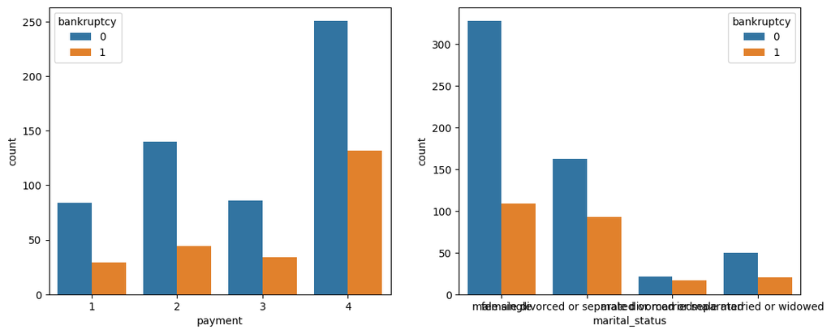

```python
plt.figure(figsize=(13,5) )
plt.subplot(1,2,1)
sns.countplot(x="payment", hue='bankruptcy',  data=train)

plt.subplot(1,2,2)
sns.countplot(x="marital_status", hue='bankruptcy',  data=train)
```